# Progetto in R: Negozi di elettronica

Gruppo 5** (*William Santeramo, Davide Jemtchougov, Giacomo Amato, Maddalena Bozzola*)

13/05/2024

# 0. Overview

Abbiamo gestito il progetto attraverso Github. Questa è la repo. https://github.com/arct0r/R-Artigiani

Ci è stato affidato il compito di individuare, tra tre negozi di elettronica, quale fosse il migliore su cui investire attraverso una serie di recensioni che i brand avevano raccolto.

Ci è stato fornito un dataset che contiene le seguenti variabili:

- Social: le fonti delle recensioni;
- Text: le recensioni;
- Lang_value: lingua in cui è stata scritta;
- Data_created_at: data di inserimento della recensione;
- Count_likes: numero dei like;
- Score_Rating: una valutazione da 1 a 5;
- Player: il negozio in questione

# 1. Dataset e Pulizia

Il dataset sul quale dobbiamo effettuare analisi ha il seguente aspetto:

Dataset Negozi di Elettronica, Recensioni

| ID | social | text | lang_value | date_created_at | counts_likes | score_rating | Player |
| --- | --- | --- | --- | --- | --- | --- | --- |
| 1 | places | NA | NA | 2023-02-17T00:55:00Z | 0 | 5 | Mediaworld |
| 2 | places | OGGI 16 FEBBRAIO 2023 IL SIGNOR GIUSEPPE DEL REPARTO CONDIZIONATORI E STATO MOLTO CORTESE E HA SODDISFATTO PIENAMENTE TUTTE LE MIE RICHIESTE. GRAZIE ! | it | 2023-02-16T21:06:00Z | 0 | 5 | Mediaworld |
| 3 | places | NA | NA | 2023-02-16T04:11:00Z | 0 | 5 | Mediaworld |
| 4 | places | NA | NA | 2023-02-15T20:15:00Z | 0 | 4 | Mediaworld |
| 5 | places | NA | NA | 2023-02-15T14:34:00Z | 0 | 5 | Mediaworld |
| 6 | places | Mediaworld è una garanzia. | NA | 2023-02-15T13:55:00Z | 0 | 3 | Mediaworld |
| 7 | places | Ottimo servizio, Marco di Samsung eccezionale, per qualsiasi informazione, consigliatissimo | it | 2023-02-15T13:38:00Z | 0 | 5 | Mediaworld |

Le recensioni provengono da due fonti: places e twitter. Le lingue sono molteplici e i negozi di elettronica (Player) sono 3.

```r
table(StoresReview$lang_value)
```

```
##
##   bg   de   en   es   fr   hr   id   it   jv   ln   nl   pt   ro   ru   sr   uk
##    1    1   38   18    4    1    2 3561    1    2    3    2    2    1    1    1
```

```r
table(StoresReview$social, StoresReview$Player)
```

```
##
##           Euronics Mediaworld Unieuro
##   places       134        736     304
##   twitter      526       1328    1130
```

Nel dataset sono presenti testi vuoti:

```r
apply(StoresReview,2,function(x) sum(is.na(x)))
```

```
##              ID          social            text      lang_value date_created_at
##               0               0             458             519               0
##    counts_likes    score_rating          Player
##               0            2984               0
```

Le recensioni in italiano sono la maggioranza, decidiamo di prendere in considerazione solo quelle ed eliminiamo le altre. Il nostro dataset assume ora questo aspetto

Dataset Negozi di Elettronica, Recensioni

|  | ID | social | text | lang_value | date_created_at | counts_likes | score_rating | Player |
| --- | --- | --- | --- | --- | --- | --- | --- | --- |
| 2 | 2 | places | OGGI 16 FEBBRAIO 2023 IL SIGNOR GIUSEPPE DEL REPARTO CONDIZIONATORI E STATO MOLTO CORTESE E HA SODDISFATTO PIENAMENTE TUTTE LE MIE RICHIESTE. GRAZIE ! | it | 2023-02-16T21:06:00Z | 0 | 5 | Mediaworld |
| 6 | 6 | places | Mediaworld è una garanzia. | NA | 2023-02-15T13:55:00Z | 0 | 3 | Mediaworld |
| 7 | 7 | places | Ottimo servizio, Marco di Samsung eccezionale, per qualsiasi informazione, consigliatissimo | it | 2023-02-15T13:38:00Z | 0 | 5 | Mediaworld |
| 9 | 9 | places | Oggettivamente il miglior store di Mediaworld per pulizia per dove dislocato per esposizione e per quantità di orodotti | it | 2023-02-14T12:10:00Z | 0 | 4 | Mediaworld |
| 10 | 10 | places | Metto una stella perché meno non si può. Ragazza slav con i capelli rosa, supermaleducata, nel acquistare un monopattino mi ha obbligato a comprarlo montato e pagare 25 euro in più, alla mia risposta … | it | 2023-02-13T19:56:00Z | 0 | 1 | Mediaworld |
| 11 | 11 | places | Gentilissimo il ragazzo all’interno del negozio(Garmin) che ho visitato il pomeriggio del 15 aprile 2021. Il negozio è un po’ piccolino e si trova dentro al Mediaworld di Viale Certosa. I prezzi sono … | it | 2023-02-13T16:58:00Z | 0 | 4 | Mediaworld |
| 13 | 13 | places | ottimo servizio, personale competente e gentile | it | 2023-02-13T00:06:00Z | 0 | 5 | Mediaworld |

Creiamo il corpus e la DFM togliendo le parole non utili (#hashtags, @usernames) provenienti dai tweets.

```r
# Creazione corpus
Corpus_Totale <- corpus(Ita_StoresReview)

# Creazione dfm
Dfm_Totale <- dfm(tokens(Corpus_Totale,
                         remove_punct = TRUE,
                         remove_symbols = TRUE,
                         remove_url = TRUE,
                         remove_numbers = TRUE) %>%
                    tokens_tolower() %>%
                    tokens_remove(c(stopwords("italian"))) %>%
                    tokens_wordstem(language = "italian")) %>%
  dfm_trim(min_termfreq = 10,
           max_termfreq = 500, # Abbiamo messo un tetto per non considerare i 3 brand
           min_docfreq = 2)

# Raggruppiamo i tag e gli hashtag
Parole_Brutte <- colnames(Dfm_Totale)[grepl("^\\s*[#@]", trimws(colnames(Dfm_Totale)))]

# Li togliamo perché non ci saranno utili nell'analisi
Dfm_Totale <- Dfm_Totale[,!(colnames(Dfm_Totale) %in% Parole_Brutte)]

# check
dim(Dfm_Totale) # 3622 testi e 869 features
```

```
## [1] 3622  869
```

# 2. Analisi del sentiment con algoritmi supervisionati

Durante la fase di recensione manuale del sentiment ci siamo accorti che la maggior parte dei text proveniva da twitter, questi erano quasi tutti neutrali e non ci è sembrato che avessero particolare utilità.

Per questo motivo abbiamo deciso di creare un training data (n=200) composto all’80% da places e al 20% da tweets.

## 2.1 Preparazione dei dati per gli algoritmi

Procediamo con il campionamento casuale:

```r
set.seed(001)
Training_places <- sample(Corpus_Totale[attr(Corpus_Totale, "docvars")$social == "places"],  size = 160,  replace = FALSE)
set.seed(002)
Training_tweet <- sample(Corpus_Totale[attr(Corpus_Totale, "docvars")$social == "twitter"], size = 40, replace = FALSE)
```

```r
# Dataframe del Campione per poterlo esportare
Campione <- data.frame(
  ID = attr(Training_Corpus, "docvars")$ID,
  persona <- rep(c("William","Davide","Maddalena","Giacomo"),each = 50),
  Training_Corpus,
  sentiment <- NA) # facilita le verifica dopo
names(Campione) <- c("ID","Persona","text","sentiment")
# Rinominazione necessaria per far riconoscere ad RStudio il text field

Campione <- read_excel("Training Data Grezzo.xlsx")

Campione$sentiment <- ifelse(Campione$sentiment == -1, "Negativo",
                             ifelse(Campione$sentiment == 0, "Neutro",
                                    "Positivo"))
```

Analisi manuale

| ID | Persona | text | sentiment |
| --- | --- | --- | --- |
| 2150 | William | Uscire con la polo blu non è stata la scelta migliore considerando che dovevo andare a fare acquisti a Unieuro | Neutro |
| 1884 | William | PERCHE’ UNIEURO BATTE FORTE SEMPRE | Neutro |
| 3999 | William | cioè in realtà so essere anche molto estroversa all’uni, MA SICURAMENTE NON LO SONO DA EURONICS NEL REPARTO NINTENDO | Neutro |
| 1590 | William | Vero fuoritutto Unieuro: tantissimi prodotti tech in offerta! - https://t.co/doBICuDzIDhttps://t.co/DVagFErtst via @GoogleNews #Scienza e #tecnologia | Neutro |
| 1566 | William | @Unieuro buongiorno ho bisogno di integrare il numero civico del mio indirizzo il sistema non me lo permette mi potete contattare? Grazie, Sergio | Neutro |
| 1447 | William | @Barbarab1974FAN @luiginadg @g_sangiuliano Io invece unieuro…sui volantini ??? | Neutro |
| 2548 | William | Questa cosa mi ha ricordato quando aprì mediaworld che mise, tra le altre cose, le psp a prezzo bassissimo. C’era uno con le stampelle che correva più di me | Neutro |

Il numero delle features del training data e del testing data risultano le seguenti:

```r
length(Dfm_Training@Dimnames$features) #1235
```

```
## [1] 1235
```

```r
length(Dfm_Test@Dimnames$features) #8533
```

```
## [1] 8533
```

```r
# Abbasso il numero di features del test
Dfm_Test <- dfm_match(Dfm_Test,
                      features = featnames(Dfm_Training))
# Dopo il match lunghezzze pari a 1235
```

[output not shown]

## 2.2 Training e classificazione

Cominciamo creando ed allenando l’algoritmo di Bayes:

```r
# ALGORITMO NAIVE BAYES
set.seed(123)
NaiveBayesModel <- multinomial_naive_bayes(x=Matrice_Training,
                                           y=Dfm_Training@docvars$sentiment,
                                           laplace = 1)
# Distribuzione del sentiment sul training
summary(NaiveBayesModel)
```

```
##
## =========================== Multinomial Naive Bayes ============================
##
## - Call: multinomial_naive_bayes(x = Matrice_Training, y = Dfm_Training@docvars$sentiment,      laplace = 1)
## - Laplace: 1
## - Classes: 3
## - Samples: 200
## - Features: 1235
## - Prior probabilities:
##     - Negativo: 0.23
##     - Neutro: 0.225
##     - Positivo: 0.545
##
## --------------------------------------------------------------------------------
```

Procediamo con la predizione usando l’algoritmo (di Bayes) appena allenato.

```r
# Predizione sul test set
Test_predictedNB <- predict(NaiveBayesModel,
                            Matrice_Test)

# frequenze assolute sui 3400 testi del test
table(Test_predictedNB)
```

```
## Test_predictedNB
## Negativo   Neutro Positivo
##     1145      886     1369
```

Iniziamo il primo training del random forest con 500 trees.

```r
# ALGORITMO RANDOM FOREST
set.seed(150)
RF <- randomForest(y= Dfm_Training@docvars$sentiment,
                   x= Matrice_Training,
                   importance=TRUE,
                   do.trace=FALSE,
                   ntree=500) # numero standard
RF # Error rate: 31%
```

```
##
## Call:
##  randomForest(x = Matrice_Training, y = Dfm_Training@docvars$sentiment,      ntree = 500, importance = TRUE, do.trace = FALSE)
##                Type of random forest: classification
##                      Number of trees: 500
## No. of variables tried at each split: 35
##
##         OOB estimate of  error rate: 31%
## Confusion matrix:
##          Negativo Neutro Positivo class.error
## Negativo       11      1       34  0.76086957
## Neutro          3     20       22  0.55555556
## Positivo        1      1      107  0.01834862
```

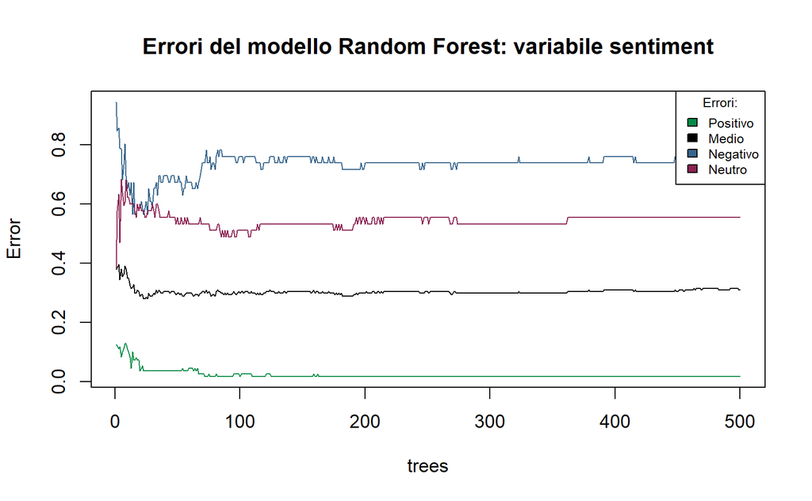

Random Forest, errori

Identifichiamo il numero di trees minimi che commettono l’errore minore.

```r
# Salvo tutti gli errori relativi al numero dei trees
Errori <- as.data.frame(RF$err.rate)

# Identifico il PRIMO numero di ntrees con l'errore minimo
which.min(Errori$OOB) # 23
```

```
## [1] 23
```

Sperimentiamo riallenando il Random Forest con 23 trees.

```r
# Rifacciamo con ntree = 23
set.seed(150)
RF <- randomForest(y= Dfm_Training@docvars$sentiment,
                   x= Matrice_Training,
                   importance=TRUE,
                   do.trace=FALSE,
                   ntree=23)
RF # 28% error rate
```

```
##
## Call:
##  randomForest(x = Matrice_Training, y = Dfm_Training@docvars$sentiment,      ntree = 23, importance = TRUE, do.trace = FALSE)
##                Type of random forest: classification
##                      Number of trees: 23
## No. of variables tried at each split: 35
##
##         OOB estimate of  error rate: 28%
## Confusion matrix:
##          Negativo Neutro Positivo class.error
## Negativo       20      0       26  0.56521739
## Neutro          7     19       19  0.57777778
## Positivo        2      2      105  0.03669725
```

Ripetiamo la predizione.

```r
Test_predictedRF <- predict(RF, Matrice_Test ,type="class")

table(Test_predictedRF)
```

```
## Test_predictedRF
## Negativo   Neutro Positivo
##      148       28     3224
```

Ora creiamo ed allenaniamo il Support Vector Machine.

```r
# SUPPORT VECTOR
set.seed(175)
SupportVectorMachine <- svm(
  y= Dfm_Training@docvars$sentiment,
  x=Matrice_Training, kernel='linear', cost = 1)

length(SupportVectorMachine$index) # 173 support vector
```

```
## [1] 173
```

Predizioni del Support Vector Machine:

```r
Test_predictedSV <- predict(SupportVectorMachine, Matrice_Test)

table(Test_predictedSV)
```

```
## Test_predictedSV
## Negativo   Neutro Positivo
##      304      337     2759
```

Abbiamo allenato 3 diversi algoritmi sul nostro training data con il sentiment recensito manualmente. Bayes, Random Forest e Support Vector Machine.

Questo è un sample del loro risultato. In seguito analizzeremo più a fondo le loro performances attraverso il processo di cross validation.

```r
# frequenze relative dei diversi algoritmi
results <- as.data.frame(rbind(prop.table(table(Test_predictedNB)),
                               prop.table(table(Test_predictedRF)),
                               prop.table(table(Test_predictedSV))))

results$algorithm <- c("Naive Bayes", "Random Forest", "Support Vector Machine")

df.long<-melt(results,id.vars=c("algorithm"))
```

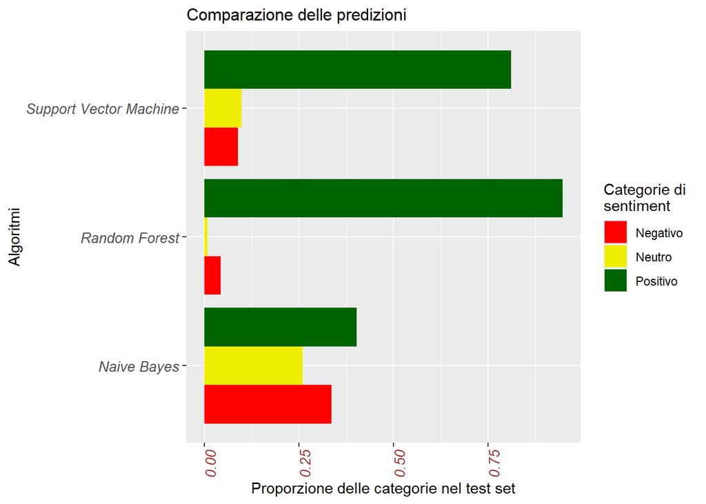

Wow! Che sta succedendo qui? I nostri algoritmi stanno dando valutazioni completamente diverse! Quale sarà il migliore?

## 2.3 Cross validation

Per la cross validation abbiamo scelto un numero di subset pari a 5 (k=5).

Misuriamo l’accuracy ed f1 score dei tre algoritmi:

```r
# ACCURACY BAYES
AverageAccuracy_NB # 81,5%
```

```
## [1] 0.815
```

```r
AverageF1_NB # 72,7%
```

```
## [1] 0.7267172
```

**Wow!!!!!!!!!!!!** 81%. Un risultato strabiliante.

Nonostante abbiamo diminuito il numero di trees l’accuracy risulta inferiore rispetto a Bayes.

```r
# ACCURACY RANDOM FOREST
AverageAccuracy_RF # 67,5%
```

```
## [1] 0.675
```

```r
AverageF1_RF  #52,6%
```

```
## [1] 0.5259117
```

```r
# ACCURACY SUPPORT VECTOR MACHINE
AverageAccuracy_SVM # 73%
```

```
## [1] 0.73
```

```r
AverageF1_SVM # 62,2%
```

```
## [1] 0.6223558
```

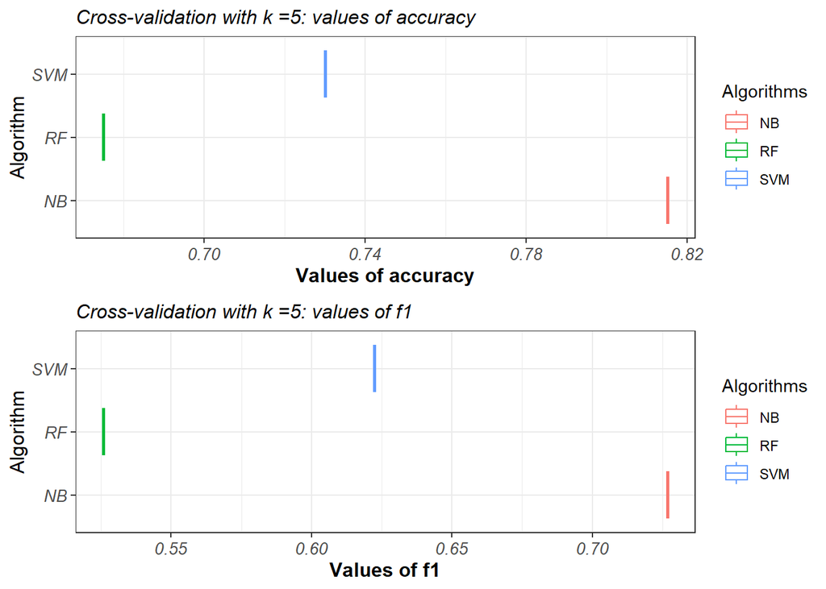

```r
grid.arrange(plot_accuracy, plot_f1, nrow=2) #bayes
```

Determiniamo così che Bayes è l’algoritmo più performante

[figure not shown]

## 2.4 AAP (Actual Algorythm Performance)

Il test che è stato creato per valutare le prestazioni degli algoritmi sul set di dati di testing è conosciuto come cross validation. Grazie a questa tecnica, siamo in grado di comprendere come gli algoritmi si comportino con il set di dati di addestramento.

Tuttavia, non abbiamo informazioni sull’accuratezza degli algoritmi con il set di dati di testing. Pertanto, è stato ideato l’AAP (Actual Algorithm Performances).

Abbiamo estratto un campione di testi (60 testi) dal testing data e li abbiamo recensiti manualmente. Abbiamo posizionato queste recensioni di fianco a quelle degli algoritmi.

Abbiamo infine calcolato l`accuracy di tutti e tre gli algoritmi in questo campione. Queste sono state le performances:

Dataset Negozi di Elettronica, Recensioni

| ID | social | Test_Corpus | Test_predictedNB | Test_predictedRF | Test_predictedSV | human_val |
| --- | --- | --- | --- | --- | --- | --- |
| 659 | places | Vasto assortimento di elettronica a prezzi interessanti e di erse offerte | Positivo | Positivo | Positivo | Positivo |
| 1133 | places | Negozio di elettronica ben fornito. Ampio reparto per la vendita di grandi e piccoli elettrodomestici. | Positivo | Positivo | Positivo | Positivo |
| 1032 | places | Non rispettano gli orari di apertura e chiusura del negozio. Nel giorno 06/08, non festivo, il negozio risultava chiuso anticipatamente rispetto all’orario prefissato delle 20:30. | Negativo | Positivo | Positivo | Negativo |
| 1158 | places | ambiente meno socevole di quello di B:ires purtroppo chiuso. Servite però da una sognora di mezza eta’molto professionale e gentilìssima consigliate bene mentre l’altro personale piuttosto distratto n… | Positivo | Positivo | Positivo | Positivo |
| 253 | places | Provo a ripubblicare il post. Lascio una stella perché il prodotto è valido e la persona che ha fatto consulenza molto cortese. Ma l’esperienza legata alla consegna da parte degli incaricati da Mediaw… | Negativo | Positivo | Positivo | Neutro |
| 426 | places | Ci siamo recati nel reparto TV al primo piano per acquistarne uno nuovo. Siamo stati accolti da Anna di Panasonic, un venditore che si è proposto in maniera gentile e per nulla invadente, seguendoci n… | Positivo | Positivo | Positivo | Positivo |
| 597 | places | Personale gentilissimo e disponibile. Ottimi prezzi | Positivo | Positivo | Positivo | Positivo |

Abbiamo infine calcolato l’accuracy di tutti e tre gli algoritmi in questo campione. Queste sono state le performances:

```r
round(AAP_confronto[2,],2)
```

```
##               Bayes RF    SV
## Freq Relativa 71.67 55 58.33
```

Rispetto alla cross validation Bayes rimane il piu’ performante ma ha comunque registrato un calo di prestazioni.

Essendo la stragrande maggioranza dei tweets inutili sarebbe interessante capire come il quantitativo di questi nel campione influenza l’accuracy.

# 3. Driver Analysis

Frequenze delle caratteristiche del Corpus

```r
# Frequenze delle caratteristiche del Corpus
apply(textstat_summary(Corpus_Totale)[,2:11], 2, sum)
```

```
##   chars   sents  tokens   types  puncts numbers symbols    urls    tags  emojis
##  591315    6381  104356   86797   13932    1996     494    1014    4023      16
```

Notiamo la presenza di emoji, tag, urls e altri elementi disturbanti per l’analisi.

Abbiamo voluto prendere in considerazione solo le recensioni di places per individuare i possibili driver del dataset.

```r
# Abbiamo voluto prendere in considerazione solo le recensioni di places
# per individuare i possibili driver del dataset.
Dfm_Places <- dfm(tokens(Corpus_Totale[attr(Corpus_Totale, "docvars")$social == "places"],
                         remove_punct = TRUE,
                         remove_symbols = TRUE,
                         remove_url = TRUE,
                         remove_numbers = TRUE) %>%
                    tokens_tolower() %>%
                    tokens_remove(c(stopwords("italian"))) %>%
                    tokens_wordstem(language = "italian")) %>%
  dfm_trim(min_termfreq = 10,
           max_termfreq = 500, # Abbiamo messo un tetto per non considerare i 3 brand
           min_docfreq = 2)
```

RILEVAZIONE DELLE KEYWORDS

```r
# Vogliamo rappresentare le top 50 sui grafici
Parole_Popolari <- textstat_frequency(Dfm_Places, n =50)
Parole_Popolari$feature <- with(Parole_Popolari, reorder(feature, frequency))
```

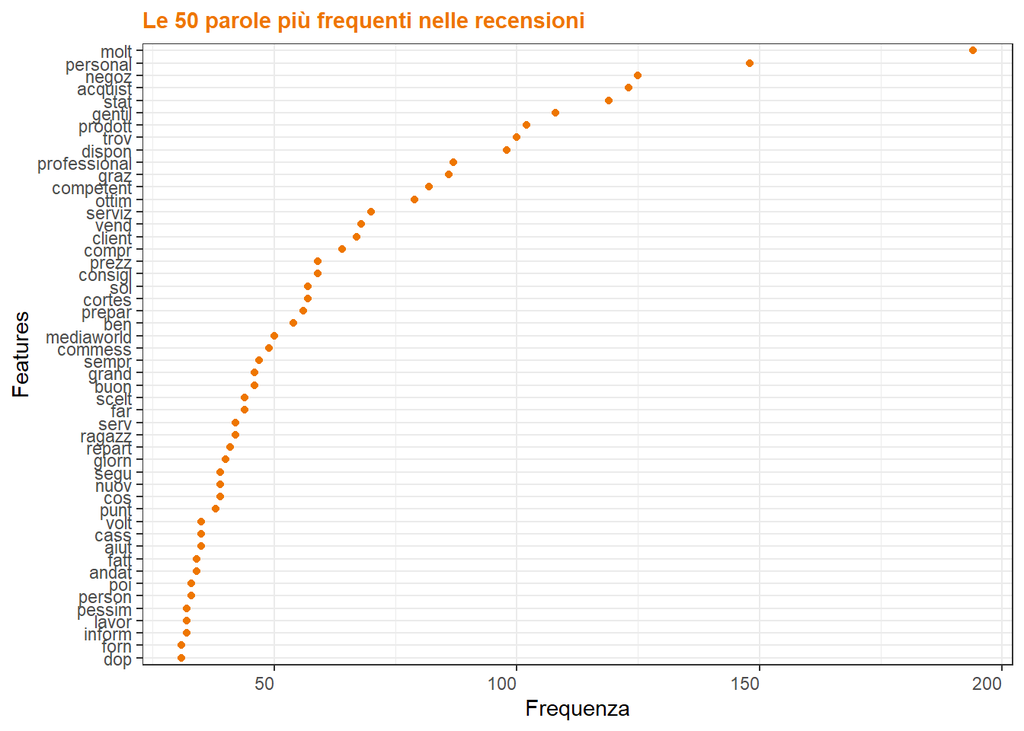

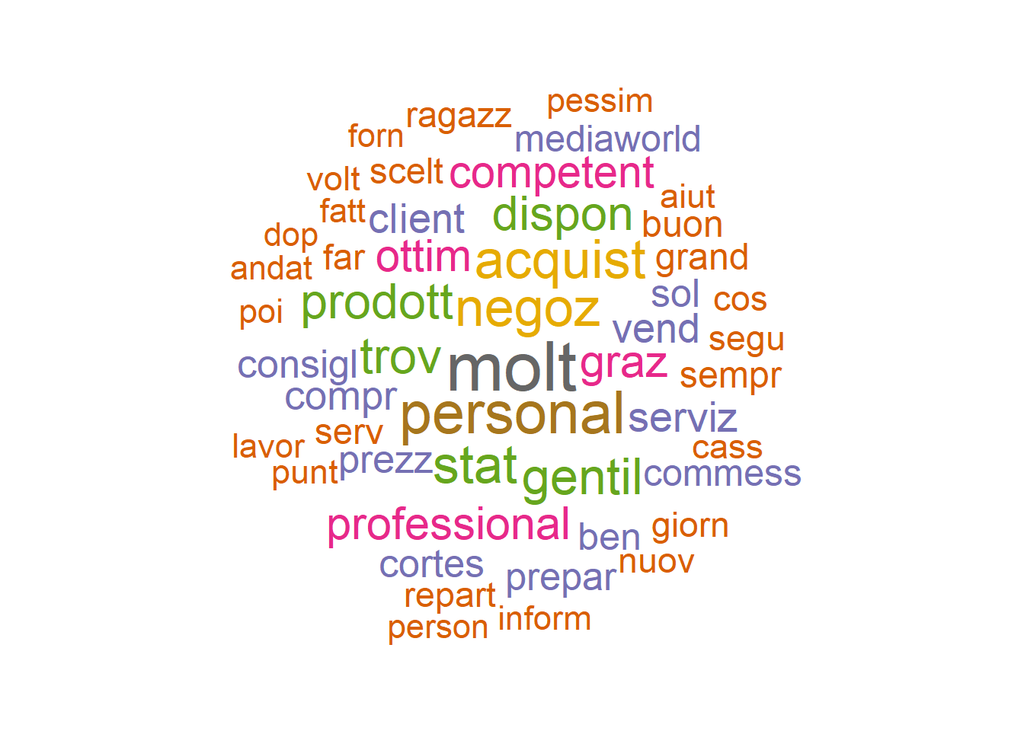

## 3.1 Scelta delle Keywords e Driver

Abbiamo individuato 4 possibili driver: Prezzo, Servizio, Ordini e Location.

Le seguenti keywords sono state in parte generate ed in parte scelte dalla lista di features. Verranno utilizzate sia per il dizionario che per l’algoritmo supervisionato.

```r
Driver <- dictionary(list(prezzo = c("promozione", "risparmio", "qualità", "prezzo", "economicità",
                                     "economico", "concorrenziali", "sconto",
                                     "offerta", "budget", "ragionevole","costo", "sostenibile",
                                     "convenienti", "sottocosto", "eccezional", "super", "miglior", "ben",
                                     "top", "futur", "offert", "convenient", "risparm", "assurd", "super", "pazzesc", "gratis"),
                          servizio =  c("rapidità", "Empatia", "professionale", "supporto",
                                        "risoluzione","problemi",  "cordialità", "assistenza", "vendita",
                                        "immediata", "efficienza", "cortese", "reclami",
                                        "competenza", "cliente", "flessibilità", "tempestività",
                                        "servizio", "accoglienza", "caloroso", "gentile", "personal", "competente", "disponibile", "male",
                                        "lento", "disorganizzato", "disordinato", "scortese", "cafone", "garanzia", "reso", "account",
                                        "signor", "reparto", "richiest", "graz", "eccezional", "inform", "miglior", "ragazz",
                                        "rispost", "gent", "gentilissim", "rispett", "competent", "bell", "ringraz", "aiut",
                                        "pront", "addett", "pessim", "pazienz", "ore", "benissim", "purtropp", "purtropp", "problem",
                                        "incompetent", "rivolg", "compl", "ben", "consigl", "prossim", "buon", "gentilezz", "educ",
                                        "simpat", "dispon", "attenzion", "qualif", "aspett", "grandissim", "disponibil", "esigent", "top",
                                        "giovan", "assist", "futur", "risolt", "bravissim", "commess", "brav", "spieg", "dubb", "vergogn",
                                        "inutil", "maleduc", "pochissim", "signorin", "bellissim", "perfett", "attent", "super",
                                        "pazzesc", "soluzion", "difett", "truff", "qualit", "normal", "scortes", "intelligent"),
                          ordini = c("transazione", "acquisto", "pagamento", "tempo", "consegna",
                                     "ordine", "opzioni", "modalità", "ritiro",
                                     "rimborso", "conferma", "tracciabilità", "facilità",
                                     "catalogo", "online","checkout", "garanzia", "reso", "account", "bell", "pessim", "nuov",
                                     "benissim", "purtropp", "problem", "ben", "buon", "aspett", "attesa", "top", "futur", "risolt",
                                     "vergogn", "inutil", "bellissim", "assurd", "super", "difett", "truff"),
                          location = c("accesso", "facilitato", "ampio", "parcheggio", "zona", "geografica",
                                       "ambiente", "accogliente", "strutture", "moderne",
                                       "punto", "vendita", "facilità", "raggiungimento", "accessibilità", "disabili",
                                       "prossimità","area", "centrale", "sicurezza", "atmosfera", "piacevole", "posizione","strategica",
                                       "illuminata", "spazio", "facile",
                                       "tranquilla", "negozio", "posto", "affollato", "piccolo", "disordinato", "bell", "ben")))
```

Questi sono i numeri di features per ogni categoria.

- Prezzo: 27
- Servizio: 101
- Ordini: 39
- Location: 35

Abbiamo applicato lo stemming alle keywords.

```r
# Funzione che applicherà lo stemming sulle keywords del driver
stem_words <- function(words) {
  stemmed_words <- wordStem(words, language = "italian")
  return(stemmed_words)
}
```

```r
Driver_Conv_Rev <- convert(Driver_Review, to = "data.frame")
Driver_Conv_Rev <- cbind(ID = Dfm_Totale@docvars$ID, Driver_Conv_Rev)

apply(Driver_Conv_Rev[,3:6],2,sum) # Numero di testi etichettati per driver
```

```
##   prezzo servizio   ordini location
##     1549     3555     2061     1058
```

```r
prop.table(apply(Driver_Conv_Rev[,3:6],2,sum)) # Distribuzione dei driver
```

```
##    prezzo  servizio    ordini  location
## 0.1883741 0.4323240 0.2506385 0.1286635
```

```r
DriverAnalysis <- full_join(Ita_StoresReview, Driver_Conv_Rev)
```

## 3.2 Sentiment Analysis

Mettiamo a confronto attraverso un grafico sentiment e rating, i sentiment “positivo” “negativo” vengono messi in relazione con ogni livello del rating

```r
Dizionario <- get_sentiment_dictionary(dictionary = 'nrc',
                                       language = "italian")

Store_reviews_sentiment <- get_sentiment(Corpus_Totale,
                                                      method = 'nrc', language = "italian")

DriverAnalysis$sentimentAnalysis <- Store_reviews_sentiment

DriverAnalysis$sentiment_labels <- ifelse(DriverAnalysis$sentimentAnalysis <= 0, "Negativo", "Positivo")
```

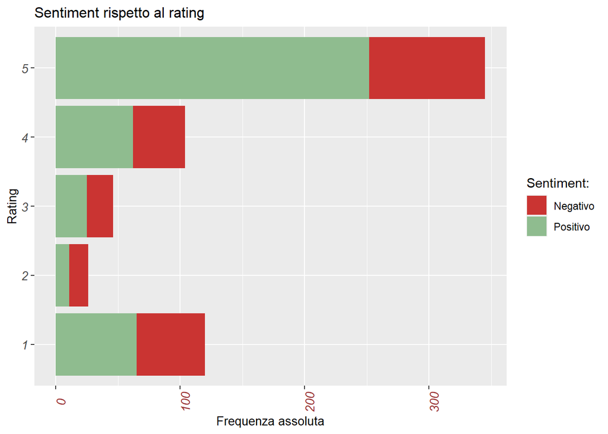

## 3.3 Emotion Analysis

Con un grafico osserviamo come, in proporzione, le varie emozioni si presentano nelle recensioni.

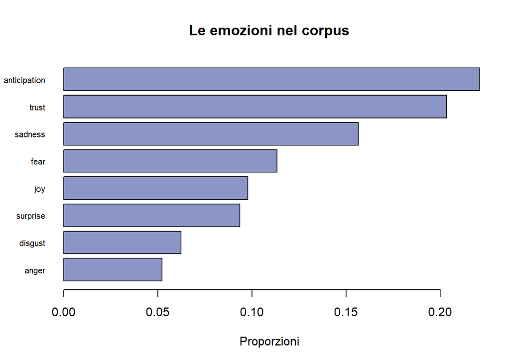

EmotionAnalysis

## 3.4 Newsmap

Seconda parte dell’analisi, qui lavoriamo con l’algoritmo semi supervisionato.

```r
round(prop.table(table(predict(TextModel))), 2)*100 # % driver nel dataset
```

```
##
##   prezzo servizio   ordini location
##       26       28       23       23
```

```r
DriverAnalysis$Dizionario <- ifelse(DriverAnalysis$prezzo > 0, "Prezzo",
                                    ifelse(DriverAnalysis$servizio > 0, "Servizio",
                                           ifelse(DriverAnalysis$ordini > 0, "Ordini",
                                                  ifelse(DriverAnalysis$location > 0, "Location", "NA"))))

ConfrontoRisultati <- filter(DriverAnalysis, Dizionario == "NA")
# Colonna inutile
DriverAnalysis$doc_id <- NULL
```

# 4. Conclusioni e considerazioni

Vogliamo basarci sui risultati dell’algoritmo semi-supervisionato, ma si nota la presenza di NA nelle colonne Player e del semi-supervisionato.

```r
apply(DriverAnalysis, 2, function(x) sum(is.na(x)))
```

```
##                ID            social              text        lang_value
##                 0                22                22                83
##   date_created_at      counts_likes      score_rating            Player
##                22                22              2981                22
##      NB_sentiment            prezzo          servizio            ordini
##                22                 0                 0                 0
##          location sentimentAnalysis  sentiment_labels    SemiSupervised
##                 0                 0                 0                83
##        Dizionario
##                 0
```

## 4.1 Conclusioni generali

Per interpretare i dati procediamo con la creazione di grafici che ci permettano di vedere nel dettaglio sentiment, rating e driver.

In questa tabella visualizziamo i valori medi di rating e sentiment nei tre brand, inseriamo anche il numero totale di recensioni. Scegliamo di assegnare il livello di intensità colore in base al peso del valore.

```r
# TABELLA GENERALE
# Recensioni, rating e sentiment in base al brand
Generale <- DriverAnalysis %>%
  group_by(Player) %>%
  summarise(n_rec = length(text),
            media_rating = round(mean(score_rating,na.rm = TRUE),2),
            media_sentiment = round(mean(sentimentAnalysis),2))

# Pre ottenere una tabella a colori abbiamo usato una funzione alternativa
Generale_ft <- flextable(Generale)

Generale_ft |>
  bg(j = c("media_rating","media_sentiment"),
     bg = scales::col_quantile(palette = c("wheat", "red"), domain =NULL))
```

| Player | n_rec | media_rating | media_sentiment |
| --- | --- | --- | --- |
| Euronics | 584 | 4.11 | 0.62 |
| Mediaworld | 1,728 | 3.98 | 0.86 |
| Unieuro | 1,205 | 3.05 | 0.43 |

```r
# Colora in base al peso del valore
```

Notiamo che il brand con il rating più alto è Euronics, che supera di poco Mediaworld, Mediaworld però ha una media di sentiment decisamente più alta, probabilmente il fatto che il numero di recensioni di Euronics sia più basso va ad impattare sulla media del rating.

Creiamo poi un grafico che mostra in che modo si distribuisce il sentiment nei tre brand nel dettaglio. Mediaworld ha i valori di positivi più alti.

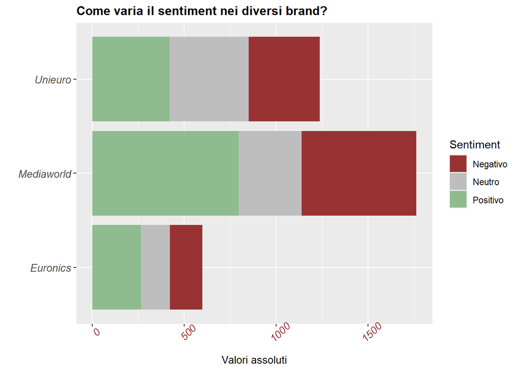

Facciamo lo stesso con i rating.

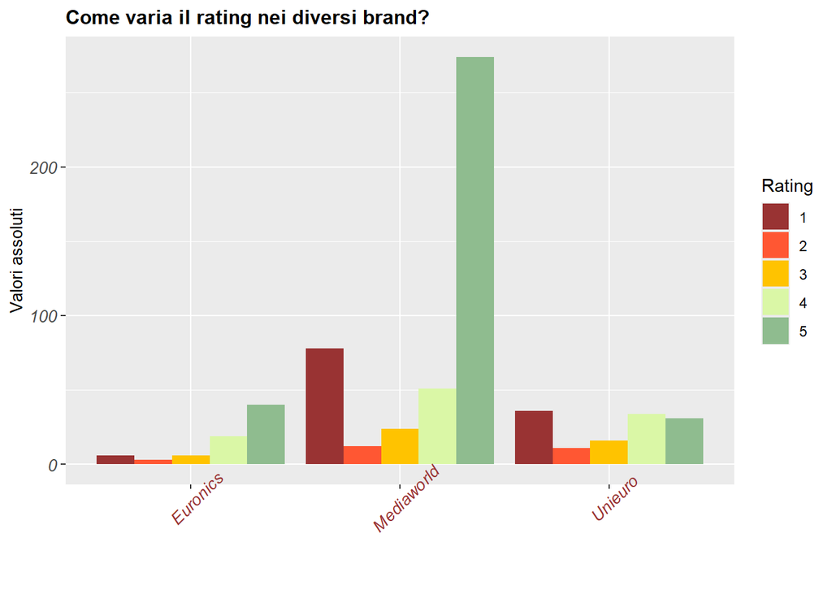

Attraverso la matrice di confusione vogliamo controllare qual è il livello di correlazione tra rating e sentiment.

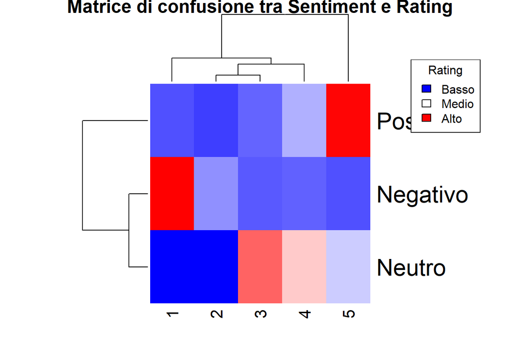

```r
# RELAZIONE TRA SENTIMENT E RATING
cross_tab <- table(Ita_StoresReview$NB_sentiment, Ita_StoresReview$score_rating)

# Creazione di un grafico a matrice di confusione
heatmap(cross_tab, col = colorRampPalette(c("blue", "white", "red"))(256), main = "Matrice di confusione tra Sentiment e Rating")
legend("topright", legend = c("Basso", "Medio", "Alto"), fill = c("blue", "white", "red"), title = "Rating")
```

## 4.2 Conclusioni sulla driver analysis

Creiamo una tabella riassuntiva per le medie di sentimet, rating, driver per ogni brand.

```r
# TABELLA DRIVER SENTIMENT

# L'obiettivo è di "ripetere" 4 volte la tabella di prima, ma relativi ai singoli driver
for (i in levels(DriverAnalysis$SemiSupervised)){

  df_i <- DriverAnalysis %>%
    filter(SemiSupervised == i)

  summary_i <- df_i %>%
    group_by(Player) %>%
    summarise(n_rev = length(text),
              media_rating = round(mean(score_rating,na.rm = TRUE),2),
              media_sentiment = round(mean(sentimentAnalysis),2))

 Generale <- inner_join(Generale,summary_i,
                           by = "Player")
} # Si appicica a destra della tabella precedente per avere una paronamica su tutti i driver


names(Generale) <- c("Player", rep(c("Numero reviews","Media score","Media sentiment"),
                                     length(levels(DriverAnalysis$SemiSupervised))+1))
```

| Player | Generale Numero reviews | Generale Media score | Generale Media sentiment | Prezzo Numero reviews | Prezzo Media score | Prezzo Media sentiment | Servizio Numero reviews | Servizio Media score | Servizio Media sentiment | Ordini Numero reviews | Ordini Media score | Ordini Media sentiment | Location Numero reviews | Location Media score | Location Media sentiment |
| --- | --- | --- | --- | --- | --- | --- | --- | --- | --- | --- | --- | --- | --- | --- | --- |
| Euronics | 584 | 4.11 | 0.62 | 148 | 4.14 | 0.32 | 155 | 4.16 | 0.88 | 131 | 3.75 | 0.51 | 150 | 3.83 | 0.76 |
| Mediaworld | 1728 | 3.98 | 0.86 | 414 | 4.00 | 0.25 | 588 | 4.23 | 1.57 | 390 | 2.50 | 0.67 | 336 | 3.45 | 0.60 |
| Unieuro | 1205 | 3.05 | 0.43 | 360 | 3.00 | 0.22 | 249 | 3.15 | 0.51 | 280 | 2.59 | 0.36 | 316 | 3.09 | 0.67 |

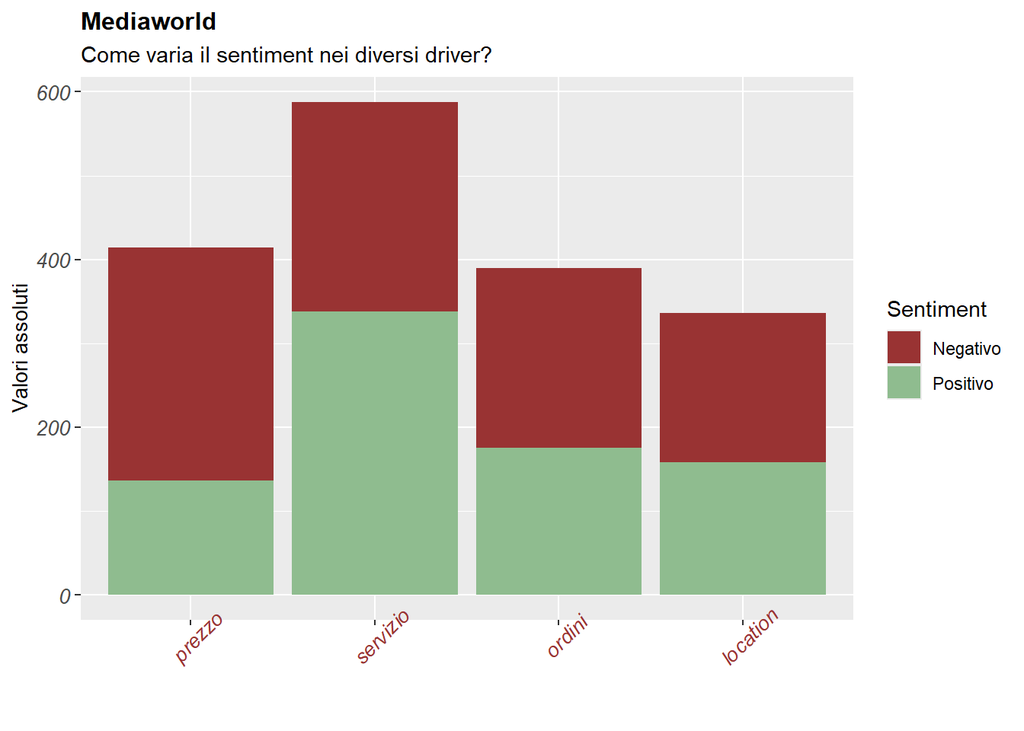

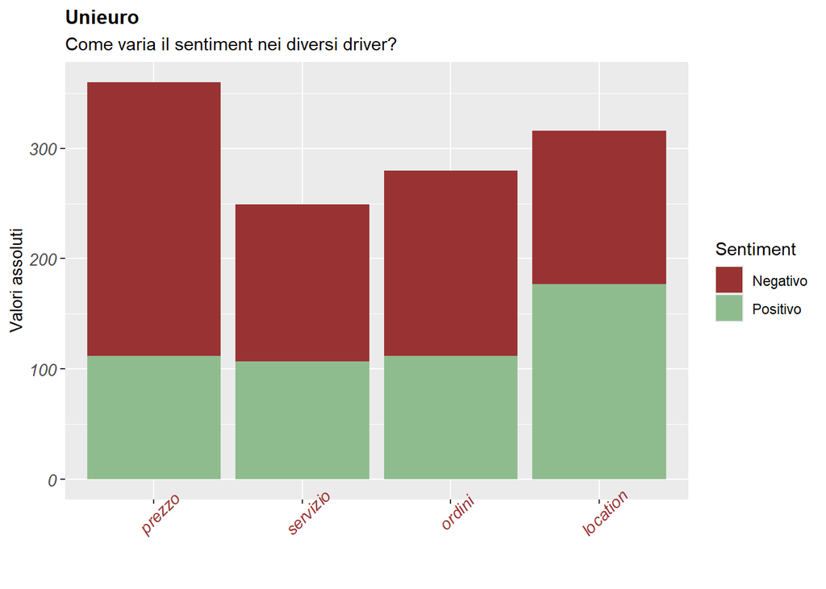

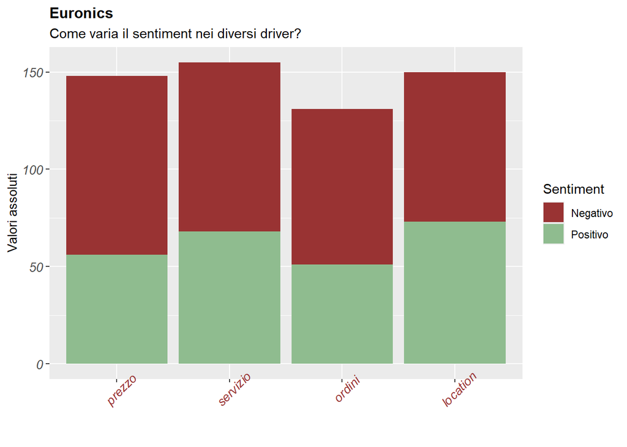